# Data Structures and Algorithms Notes

### Question 5: Reduced Data

Assign to the variable `reduced_data` the pandas matrix that does not include the columns of Cabin, Embarked and SibSp. Then execute the cell below for testing with the ok system.

```python
# Change the next line so that it computes the reduced data matrix.
reduced_data = data.drop(['Cabin', 'Embarked', 'SibSp'], axis=1)

# We've put this line in this cell so that it will print
# the value you've given to reduced_data when you
# run it.  You don't need to change this.
reduced_data.head()
```

|  | PassengerId | Survived | Pclass | Name | Sex | Age | Parch | Ticket | Fare |
| --- | --- | --- | --- | --- | --- | --- | --- | --- | --- |
| 0 | 1 | 0 | 3 | Braund, Mr. Owen Harris | male | 22.0 | 0 | A/5 21171 | 7.2500 |
| 1 | 2 | 1 | 1 | Cumings, Mrs. John Bradley (Florence Briggs Th... | female | 38.0 | 0 | PC 17599 | 71.2833 |
| 2 | 3 | 1 | 3 | Heikkinen, Miss. Laina | female | 26.0 | 0 | STON/O2. 3101282 | 7.9250 |
| 3 | 4 | 1 | 1 | Futrelle, Mrs. Jacques Heath (Lily May Peel) | female | 35.0 | 0 | 113803 | 53.1000 |
| 4 | 5 | 0 | 3 | Allen, Mr. William Henry | male | 35.0 | 0 | 373450 | 8.0500 |

```python
# Test cell; please do not change!
_ = ok.grade('q5')
```

Apart from deleting, you can also replace values by new ones. Remember that the main purpose of pandas is statistical computation, hence we often translate values to numbers that we know how to process.

For instance, strings, such as 'male' or 'female' are not really useful for statistical analysis. We usually prefere to replace them with numerical values:

```python
data.replace('male', 1).head(5)
```

|  | PassengerId | Survived | Pclass | Name | Sex | Age | SibSp | Parch | Ticket | Fare | Cabin | Embarked |
| --- | --- | --- | --- | --- | --- | --- | --- | --- | --- | --- | --- | --- |
| 0 | 1 | 0 | 3 | Braund, Mr. Owen Harris | 1 | 22.0 | 1 | 0 | A/5 21171 | 7.2500 | NaN | S |
| 1 | 2 | 1 | 1 | Cumings, Mrs. John Bradley (Florence Briggs Th... | female | 38.0 | 1 | 0 | PC 17599 | 71.2833 | C85 | C |
| 2 | 3 | 1 | 3 | Heikkinen, Miss. Laina | female | 26.0 | 0 | 0 | STON/O2. 3101282 | 7.9250 | NaN | S |
| 3 | 4 | 1 | 1 | Futrelle, Mrs. Jacques Heath (Lily May Peel) | female | 35.0 | 1 | 0 | 113803 | 53.1000 | C123 | S |
| 4 | 5 | 0 | 3 | Allen, Mr. William Henry | 1 | 35.0 | 0 | 0 | 373450 | 8.0500 | NaN | S |

As with drop, the replace function returns a copy, so keep in mind that if you want to save them, you have to assign to a new variable.

```python
# # An alternative way to replace the data is the following:
data['Sex'] = data['Sex'].map({'female': 1, 'male': 0})
```

```python
data.head(5)
```

|  | PassengerId | Survived | Pclass | Name | Sex | Age | SibSp | Parch | Ticket | Fare | Cabin | Embarked |
| --- | --- | --- | --- | --- | --- | --- | --- | --- | --- | --- | --- | --- |
| 0 | 1 | 0 | 3 | Braund, Mr. Owen Harris | 0 | 22.0 | 1 | 0 | A/5 21171 | 7.2500 | NaN | S |
| 1 | 2 | 1 | 1 | Cumings, Mrs. John Bradley (Florence Briggs Th... | 1 | 38.0 | 1 | 0 | PC 17599 | 71.2833 | C85 | C |
| 2 | 3 | 1 | 3 | Heikkinen, Miss. Laina | 1 | 26.0 | 0 | 0 | STON/O2. 3101282 | 7.9250 | NaN | S |
| 3 | 4 | 1 | 1 | Futrelle, Mrs. Jacques Heath (Lily May Peel) | 1 | 35.0 | 1 | 0 | 113803 | 53.1000 | C123 | S |
| 4 | 5 | 0 | 3 | Allen, Mr. William Henry | 0 | 35.0 | 0 | 0 | 373450 | 8.0500 | NaN | S |

```python
# # Right after the Sex, we want to include a new field named 'Nationality'.
# # Since most of the passengers are Irish, we will by default assign
# # the label 'Irish' to them and refine for those that are not.
data.insert(5, 'Nationality', 'Irish')

data.head(5)
```

|  | PassengerId | Survived | Pclass | Name | Sex | Nationality | Age | SibSp | Parch | Ticket | Fare | Cabin | Embarked |
| --- | --- | --- | --- | --- | --- | --- | --- | --- | --- | --- | --- | --- | --- |
| 0 | 1 | 0 | 3 | Braund, Mr. Owen Harris | 0 | Irish | 22.0 | 1 | 0 | A/5 21171 | 7.2500 | NaN | S |
| 1 | 2 | 1 | 1 | Cumings, Mrs. John Bradley (Florence Briggs Th... | 1 | Irish | 38.0 | 1 | 0 | PC 17599 | 71.2833 | C85 | C |
| 2 | 3 | 1 | 3 | Heikkinen, Miss. Laina | 1 | Irish | 26.0 | 0 | 0 | STON/O2. 3101282 | 7.9250 | NaN | S |
| 3 | 4 | 1 | 1 | Futrelle, Mrs. Jacques Heath (Lily May Peel) | 1 | Irish | 35.0 | 1 | 0 | 113803 | 53.1000 | C123 | S |
| 4 | 5 | 0 | 3 | Allen, Mr. William Henry | 0 | Irish | 35.0 | 0 | 0 | 373450 | 8.0500 | NaN | S |

So far, we have replaced the values of a complete column, however what if we want to perform some modifications in specific values per row (e.g. if a condition is true)?

```python
# # Let's assume for a moment that the nationality of
# # those with Age NaN is Other European (hence why there
# # are no records of their age).
# # We want to replace the default nationality with
# # their known nationality.

# # Don't worry about how this works for now, it will be clear when we cover numpy.
import numpy as np
for index, row in data.iterrows():
    if np.isnan(data.loc[index, "Age"]):
        data.loc[index, "Nationality"] = "European"
```

```python
data.head(10)
```

|  | PassengerId | Survived | Pclass | Name | Sex | Nationality | Age | SibSp | Parch | Ticket | Fare | Cabin | Embarked |
| --- | --- | --- | --- | --- | --- | --- | --- | --- | --- | --- | --- | --- | --- |
| 0 | 1 | 0 | 3 | Braund, Mr. Owen Harris | 0 | Irish | 22.0 | 1 | 0 | A/5 21171 | 7.2500 | NaN | S |
| 1 | 2 | 1 | 1 | Cumings, Mrs. John Bradley (Florence Briggs Th... | 1 | Irish | 38.0 | 1 | 0 | PC 17599 | 71.2833 | C85 | C |
| 2 | 3 | 1 | 3 | Heikkinen, Miss. Laina | 1 | Irish | 26.0 | 0 | 0 | STON/O2. 3101282 | 7.9250 | NaN | S |
| 3 | 4 | 1 | 1 | Futrelle, Mrs. Jacques Heath (Lily May Peel) | 1 | Irish | 35.0 | 1 | 0 | 113803 | 53.1000 | C123 | S |
| 4 | 5 | 0 | 3 | Allen, Mr. William Henry | 0 | Irish | 35.0 | 0 | 0 | 373450 | 8.0500 | NaN | S |
| 5 | 6 | 0 | 3 | Moran, Mr. James | 0 | European | NaN | 0 | 0 | 330877 | 8.4583 | NaN | Q |
| 6 | 7 | 0 | 1 | McCarthy, Mr. Timothy J | 0 | Irish | 54.0 | 0 | 0 | 17463 | 51.8625 | E46 | S |
| 7 | 8 | 0 | 3 | Palsson, Master. Gosta Leonard | 0 | Irish | 2.0 | 3 | 1 | 349909 | 21.0750 | NaN | S |
| 8 | 9 | 1 | 3 | Johnson, Mrs. Oscar W (Elisabeth Vilhelmina Berg) | 1 | Irish | 27.0 | 0 | 2 | 347742 | 11.1333 | NaN | S |
| 9 | 10 | 1 | 2 | Nasser, Mrs. Nicholas (Adele Achem) | 1 | Irish | 14.0 | 1 | 0 | 237736 | 30.0708 | NaN | C |

```python
# # What we've done above is to replace some of the nationalities with 'European'.
# # One property of pandas that we've utilised for that is the '.loc'.
# # Let's explore that a bit more:
print(data.loc[3])
```

```
PassengerId                                               4
Survived                                                  1
Pclass                                                    1
Name           Futrelle, Mrs. Jacques Heath (Lily May Peel)
Sex                                                       1
Nationality                                           Irish
Age                                                    35.0
SibSp                                                     1
Parch                                                     0
Ticket                                               113803
Fare                                                   53.1
Cabin                                                  C123
Embarked                                                  S
Name: 3, dtype: object
```

As can be easily verified from the print above, this provides the whole row of the 4th passenger (as Python follows zero-based indexing). In other words, data.loc is a way to index a row or even a specific 'cell' inside the row as we did above with `data.loc[index, "Nationality"]'.

```python
# # As typically done in higher level libraries in python, '.loc' offers a great deal of functionality.
# # You can find furthr information by executing data.loc??
help(data.loc)
```

[output not shown]

[output cut: 234 more lines]

[output not shown]

We can filter dataframes directly:

```python
european_bool = data['Nationality'] == 'European' # creates Booleans for each entry
print(european_bool.head(10))
# We could then pick only these records with
europeans = data[european_bool]
# If we want to count different values, we can do
data['Nationality'].value_counts()
# Counting how many non null values exist would be data['Nationality'].count()
```

```
0    False
1    False
2    False
3    False
4    False
5     True
6    False
7    False
8    False
9    False
Name: Nationality, dtype: bool
```

```
Nationality
Irish       17
European     3
Name: count, dtype: int64
```

## All done!

That's it for the recommended pandas exercises. For more practice, complete the optional exercises below. There is no submission required for the Pandas material.

## Optional exercises

### Question 6: Three Other Exercises

**A.** Can you replace the nationality column with numbers? For instance, try to assign values such that Irish = 0, Other European = 1.

**B.** How many people of European nationality are there? (Following the assumption above for the NaN in the age)

**C.** For how many passengers do we have with Cabin information?

```python
data['Nationality'] = data['Nationality'].map({'Irish': 0, 'European': 1})

data.head(10)
```

|  | PassengerId | Survived | Pclass | Name | Sex | Nationality | Age | SibSp | Parch | Ticket | Fare | Cabin | Embarked |
| --- | --- | --- | --- | --- | --- | --- | --- | --- | --- | --- | --- | --- | --- |
| 0 | 1 | 0 | 3 | Braund, Mr. Owen Harris | 0 | 0 | 22.0 | 1 | 0 | A/5 21171 | 7.2500 | NaN | S |
| 1 | 2 | 1 | 1 | Cumings, Mrs. John Bradley (Florence Briggs Th... | 1 | 0 | 38.0 | 1 | 0 | PC 17599 | 71.2833 | C85 | C |
| 2 | 3 | 1 | 3 | Heikkinen, Miss. Laina | 1 | 0 | 26.0 | 0 | 0 | STON/O2. 3101282 | 7.9250 | NaN | S |
| 3 | 4 | 1 | 1 | Futrelle, Mrs. Jacques Heath (Lily May Peel) | 1 | 0 | 35.0 | 1 | 0 | 113803 | 53.1000 | C123 | S |
| 4 | 5 | 0 | 3 | Allen, Mr. William Henry | 0 | 0 | 35.0 | 0 | 0 | 373450 | 8.0500 | NaN | S |
| 5 | 6 | 0 | 3 | Moran, Mr. James | 0 | 1 | NaN | 0 | 0 | 330877 | 8.4583 | NaN | Q |
| 6 | 7 | 0 | 1 | McCarthy, Mr. Timothy J | 0 | 0 | 54.0 | 0 | 0 | 17463 | 51.8625 | E46 | S |
| 7 | 8 | 0 | 3 | Palsson, Master. Gosta Leonard | 0 | 0 | 2.0 | 3 | 1 | 349909 | 21.0750 | NaN | S |
| 8 | 9 | 1 | 3 | Johnson, Mrs. Oscar W (Elisabeth Vilhelmina Berg) | 1 | 0 | 27.0 | 0 | 2 | 347742 | 11.1333 | NaN | S |
| 9 | 10 | 1 | 2 | Nasser, Mrs. Nicholas (Adele Achem) | 1 | 0 | 14.0 | 1 | 0 | 237736 | 30.0708 | NaN | C |

```python
# Change the next line so that it computes the number of
# people with European nationality.
n_european = data['Age'].isna().sum()

print(n_european)

# Change the next line so that it computes the number of
# people for which we have cabin information.
n_passengers_cabin = data['Cabin'].count()

print(n_passengers_cabin)
```

```
3
5
```

```python
# Test cell; please do not change!
_ = ok.grade('q6')
```

### Question 7: Assign Variables

Assign to the variable `only_pclass2` the pandas matrix that includes only the passengers with Pclass = 2. Then execute the cell below for testing with the ok system.

```python
# Change the next line so that it computes a new dataframe
# that includes only the people with Pclass = 2.
# One way to use conditions in pandas is directly with data[CONDITION]
only_pclass2 = data[data['Pclass'] == 2]

# We've put this line in this cell so that it will print
# the value you've given to only_pclass2 when you
# run it.  You don't need to change this.
only_pclass2.head()
```

|  | PassengerId | Survived | Pclass | Name | Sex | Nationality | Age | SibSp | Parch | Ticket | Fare | Cabin | Embarked |
| --- | --- | --- | --- | --- | --- | --- | --- | --- | --- | --- | --- | --- | --- |
| 9 | 10 | 1 | 2 | Nasser, Mrs. Nicholas (Adele Achem) | 1 | 0 | 14.0 | 1 | 0 | 237736 | 30.0708 | NaN | C |
| 15 | 16 | 1 | 2 | Hewlett, Mrs. (Mary D Kingcome) | 1 | 0 | 55.0 | 0 | 0 | 248706 | 16.0000 | NaN | S |
| 17 | 18 | 1 | 2 | Williams, Mr. Charles Eugene | 0 | 1 | NaN | 0 | 0 | 244373 | 13.0000 | NaN | S |

```python
# Test cell; please do not change!
_ = ok.grade('q7')
```

## Extra part: More Titanic

The Codespace contains the files `titanic.csv` and `nationalities.csv`, inside the `data/` directory. The latter file contains nationalities of Titanic passengers. Note that this file was created solely for the purpose of learning within this course, and should not be used outside of the scope of the course. It does **not** reflect the real nationalities of the passengers.

Load the files titanic.csv and nationalities.csv in the variables `data_org` and `data_nat` respectively. Remember we combine the **directory** with the **filename and extension** to create the **path to the file**. Use the cell below as instructed.

```python
import pandas as pd
```

```python
# Use Codespace for actual dataset
# Only considering 20 passengers due to limitations

titanic_csv = """PassengerId,Survived,Pclass,Name,Sex,Age,SibSp,Parch,Ticket,Fare,Cabin,Embarked
1,0,3,"Braund, Mr. Owen Harris",male,22,1,0,A/5 21171,7.25,,S
2,1,1,"Cumings, Mrs. John Bradley (Florence Briggs Thayer)",female,38,1,0,PC 17599,71.2833,C85,C
3,1,3,"Heikkinen, Miss. Laina",female,26,0,0,STON/O2. 3101282,7.925,,S
4,1,1,"Futrelle, Mrs. Jacques Heath (Lily May Peel)",female,35,1,0,113803,53.1,C123,S
5,0,3,"Allen, Mr. William Henry",male,35,0,0,373450,8.05,,S
6,0,3,"Moran, Mr. James",male,,0,0,330877,8.4583,,Q
7,0,1,"McCarthy, Mr. Timothy J",male,54,0,0,17463,51.8625,E46,S
8,0,3,"Palsson, Master. Gosta Leonard",male,2,3,1,349909,21.075,,S
9,1,3,"Johnson, Mrs. Oscar W (Elisabeth Vilhelmina Berg)",female,27,0,2,347742,11.1333,,S
10,1,2,"Nasser, Mrs. Nicholas (Adele Achem)",female,14,1,0,237736,30.0708,,C
11,1,3,"Sandstrom, Miss. Marguerite Rut",female,4,1,1,PP 9549,16.7,G6,S
12,1,1,"Bonnell, Miss. Elizabeth",female,58,0,0,113783,26.55,C103,S
13,0,3,"Saundercock, Mr. William Henry",male,20,0,0,A/5. 2151,8.05,,S
14,0,3,"Andersson, Mr. Anders Johan",male,39,1,5,347082,31.275,,S
15,0,3,"Vestrom, Miss. Hulda Amanda Adolfina",female,14,0,0,350406,7.8542,,S
16,1,2,"Hewlett, Mrs. (Mary D Kingcome) ",female,55,0,0,248706,16,,S
17,0,3,"Rice, Master. Eugene",male,2,4,1,382652,29.125,,Q
18,1,2,"Williams, Mr. Charles Eugene",male,,0,0,244373,13,,S
19,0,3,"Vander Planke, Mrs. Julius (Emelia Maria Vandemoortele)",female,31,1,0,345763,18,,S
20,1,3,"Masselmani, Mrs. Fatima",female,,0,0,2649,7.225,,C"""

nationalities_csv = """PassengerId,Nationality
1,Swede
2,Austro Hungarian
3,Swede
4,Belgian
5,Swede
6,Irish
7,English
8,Swede
9,Belgian
10,American
11,Swede
12,Austro Hungarian
13,English
14,Irish
15,Australian
16,American
17,Irish
18,Belgian
19,English
20,American"""
```

```python
# Reads the file titanic.csv
# data_org = pd.read_csv('data/titanic.csv')
data_org = pd.read_csv(StringIO(titanic_csv))

# Reads the file nationalities.csv
# data_org = pd.read_csv('data/nationalities.csv')
data_nat = pd.read_csv(StringIO(nationalities_csv))
```

## Advanced pandas dataframe processing

When working on data analysis, we often need to combine information from different sources, or produce our own data and then combine them with other sources. The pandas library offers a great deal of methods to facilitate this process. We will study below the functionality of merging datasets. We will merge the titanic.csv (original file) and the nationalities.csv (data produced by our research).

Before merging two datasets, we need to know exactly how these datasets are related, how they are structured and whether they already have some common fields.

```python
# # First, let's ensure that the two datasets have the same number of elements (passenger data).
assert data_org.shape[0] == data_nat.shape[0]
```

```python
# # Let's print the heads of the two datasets to figure out if there are any common elements.
data_org.head(5)
```

|  | PassengerId | Survived | Pclass | Name | Sex | Age | SibSp | Parch | Ticket | Fare | Cabin | Embarked |
| --- | --- | --- | --- | --- | --- | --- | --- | --- | --- | --- | --- | --- |
| 0 | 1 | 0 | 3 | Braund, Mr. Owen Harris | male | 22.0 | 1 | 0 | A/5 21171 | 7.2500 | NaN | S |
| 1 | 2 | 1 | 1 | Cumings, Mrs. John Bradley (Florence Briggs Th... | female | 38.0 | 1 | 0 | PC 17599 | 71.2833 | C85 | C |
| 2 | 3 | 1 | 3 | Heikkinen, Miss. Laina | female | 26.0 | 0 | 0 | STON/O2. 3101282 | 7.9250 | NaN | S |
| 3 | 4 | 1 | 1 | Futrelle, Mrs. Jacques Heath (Lily May Peel) | female | 35.0 | 1 | 0 | 113803 | 53.1000 | C123 | S |
| 4 | 5 | 0 | 3 | Allen, Mr. William Henry | male | 35.0 | 0 | 0 | 373450 | 8.0500 | NaN | S |

```python
data_nat.head(5)
```

|  | PassengerId | Nationality |
| --- | --- | --- |
| 0 | 1 | Swede |
| 1 | 2 | Austro Hungarian |
| 2 | 3 | Swede |
| 3 | 4 | Belgian |
| 4 | 5 | Swede |

```python
# # We are ready to perform the merging. Observe that the datasets share a common column in
# # the PassengerId, so we will use it to combine the data.
data_new = data_org.merge(data_nat, on='PassengerId')

# # Let's see what we've created now.
data_new.head(5)
```

|  | PassengerId | Survived | Pclass | Name | Sex | Age | SibSp | Parch | Ticket | Fare | Cabin | Embarked | Nationality |
| --- | --- | --- | --- | --- | --- | --- | --- | --- | --- | --- | --- | --- | --- |
| 0 | 1 | 0 | 3 | Braund, Mr. Owen Harris | male | 22.0 | 1 | 0 | A/5 21171 | 7.2500 | NaN | S | Swede |
| 1 | 2 | 1 | 1 | Cumings, Mrs. John Bradley (Florence Briggs Th... | female | 38.0 | 1 | 0 | PC 17599 | 71.2833 | C85 | C | Austro Hungarian |
| 2 | 3 | 1 | 3 | Heikkinen, Miss. Laina | female | 26.0 | 0 | 0 | STON/O2. 3101282 | 7.9250 | NaN | S | Swede |
| 3 | 4 | 1 | 1 | Futrelle, Mrs. Jacques Heath (Lily May Peel) | female | 35.0 | 1 | 0 | 113803 | 53.1000 | C123 | S | Belgian |
| 4 | 5 | 0 | 3 | Allen, Mr. William Henry | male | 35.0 | 0 | 0 | 373450 | 8.0500 | NaN | S | Swede |

```python
# # Pandas offers several convenient methods for conditional selection and actions on them.
# # For instance, above we worked on getting useful aggregate statistics
# # over the whole dataset (do you remember the commands?).
# # However, often we'd like to select only a subset of the data based on some condition.
# # For instance, let's say we would like to print the average age per class.
# # One way to do that would be to iterate over all the elements, create a list, sum them
# # and then compute the average.
# # But pandas conveniently allows us to do it with a single command.
# # It works as follows:
# # First we group the data by the class, then we ask pandas to compute the mean of the age.
print(data_new.groupby(['Pclass'])['Age'].mean())
```

```
Pclass
1    46.250000
2    34.500000
3    20.181818
Name: Age, dtype: float64
```

```python
# # In the command above, we've averaged both men and women based only on the Pclass.
# # However, we could separate the two sexes and compute the mean for each sex.
print(data_new.groupby(['Pclass', 'Sex'])['Age'].mean())
```

```
Pclass  Sex
1       female    43.666667
        male      54.000000
2       female    34.500000
        male            NaN
3       female    20.400000
        male      20.000000
Name: Age, dtype: float64
```

```python
# number of People in Class Three
data_new[data_new['Pclass'] == 3]['Sex'].count()
```

```
np.int64(13)
```

```python
# Number of Males in Class Three
data_new[data_new['Pclass'] == 3][data_new[data_new['Pclass'] == 3]['Sex'] == 'male']['Sex'].count()
```

```
np.int64(7)
```

```python
# # We will now drop few columns that contain strings to mention few methods for statistical processing.
data = data_new.drop(['Cabin', 'Name', 'Ticket', 'Embarked', 'Nationality', 'Sex'], axis=1)
```

```python
# # We can for example "clip" the values, i.e. restrict them in a chosen interval.
# # Notice that some values were greater than our upper bound, but are now
# # restricted to the maximum upper bound we set.
data.clip(lower=0, upper=40).head(5)
```

|  | PassengerId | Survived | Pclass | Age | SibSp | Parch | Fare |
| --- | --- | --- | --- | --- | --- | --- | --- |
| 0 | 1 | 0 | 3 | 22.0 | 1 | 0 | 7.250 |
| 1 | 2 | 1 | 1 | 38.0 | 1 | 0 | 40.000 |
| 2 | 3 | 1 | 3 | 26.0 | 0 | 0 | 7.925 |
| 3 | 4 | 1 | 1 | 35.0 | 1 | 0 | 40.000 |
| 4 | 5 | 0 | 3 | 35.0 | 0 | 0 | 8.050 |

```python
# # If the method we would like to apply to the data does not exist, we can use the
# # '.apply' method that allows us to choose any function to be applied to each record.
# # One way to do this is through an "anonymous" lambda function.
# # This works as defining a function without an explicit name to apply to each record
data["SurvivedPlusOne"] = data["Survived"].apply(lambda x: x + 1)
data.head(5)
```

|  | PassengerId | Survived | Pclass | Age | SibSp | Parch | Fare | SurvivedPlusOne |
| --- | --- | --- | --- | --- | --- | --- | --- | --- |
| 0 | 1 | 0 | 3 | 22.0 | 1 | 0 | 7.2500 | 1 |
| 1 | 2 | 1 | 1 | 38.0 | 1 | 0 | 71.2833 | 2 |
| 2 | 3 | 1 | 3 | 26.0 | 0 | 0 | 7.9250 | 2 |
| 3 | 4 | 1 | 1 | 35.0 | 1 | 0 | 53.1000 | 2 |
| 4 | 5 | 0 | 3 | 35.0 | 0 | 0 | 8.0500 | 1 |

**Exercise**. Who survived? Use the aggregation functions above to calculate survival probabilities based on fare classes, age, or fare paid.

```python
# Fare Class
data.groupby(['Pclass'])['Survived'].mean()
```

```
Pclass
1    0.750000
2    1.000000
3    0.307692
Name: Survived, dtype: float64
```

```python
# Age
data.groupby(['Age'])['Survived'].mean()
```

```
Age
2.0     0.0
4.0     1.0
14.0    0.5
20.0    0.0
22.0    0.0
26.0    1.0
27.0    1.0
31.0    0.0
35.0    0.5
38.0    1.0
39.0    0.0
54.0    0.0
55.0    1.0
58.0    1.0
Name: Survived, dtype: float64
```

```python
# Fair Paid
data.groupby(['Fare'])['Survived'].mean()
```

```
Fare
7.2250     1.0
7.2500     0.0
7.8542     0.0
7.9250     1.0
8.0500     0.0
8.4583     0.0
11.1333    1.0
13.0000    1.0
16.0000    1.0
16.7000    1.0
18.0000    0.0
21.0750    0.0
26.5500    1.0
29.1250    0.0
30.0708    1.0
31.2750    0.0
51.8625    0.0
53.1000    1.0
71.2833    1.0
Name: Survived, dtype: float64
```

# Trump Tweets Jupyter Notebook

*Data Structures and Algorithms*

*Imperial College Business School*

In this optional section, we will practice dealing with JSON data from Twitter's API.

## Submission

This part of the session is optional and meant to be open-ended. You don't need to submit anything.

## Trump tweets, JSON edition

Earlier in the course, we looked at some of Donald Trump's tweets that had been conveniently packaged into a CSV file that we could open as a spreadsheet. The dataset we used ended in summer 2016. What if we wanted to analyse more recent tweets? We could do this by registering for access to Twitter's API (application programming interface; Twitter's interface for anyone to access its data) and downloading the data directly using one of the libraries that Python users have developed for accessing the API.

We won't register for the API now. Instead, we'll use data maintained by Github user bpb27.

The data that we'll use has been cleaned and condensed, but resembles the output from the Twitter API. Instead of CSV, the API gives data in JSON format. We've included the file condensed_2016.json downloaded from Github in the zip file.

What is JSON data, and how can we load it into Python?

### JSON

JSON (JavaScript Object Notation, "Jason") is a common format for semi-structured data on the web. Many APIs provide data as JSON. We can open a JSON file in any text editor. It will look something like this.

```
{"countries":
  [
  {"Germany": "Berlin"},
  {"France": "Paris"},
  {"Italy": "Rome"}
  ]
}
```

This looks very much like a Python data structure with nested dictionaries and lists. A tweet from Twitter's API will look similar (some fields only here):

```
{"source": "Twitter for iPhone",
"id_str": "815271067749060609",
"text": "RT @realDonaldTrump: Happy Birthday @DonaldJTrumpJr!\nhttps://t.co/uRxyCD3hBz",
"created_at": "Sat Dec 31 18:59:04 +0000 2016",
"retweet_count": 9529,
"in_reply_to_user_id_str": null,
"favorite_count": 0,
"is_retweet": true}
```

JSON is more flexible than CSV. For example, some tweets might not include some data fields. In a CSV file, we would still include them in tabular form. In JSON, the specific key-value pair would be absent.

We can read the JSON file to Python as we would a text file, or open it in Notepad or another text editor.

```python
# Use Codespace for actual dataset
# Only considering couple few tweets due to limitations
import json

json_2016 = r"""[{"source": "Twitter for iPhone", "id_str": "815271067749060609", "text": "RT @realDonaldTrump: Happy Birthday @DonaldJTrumpJr!\nhttps://t.co/uRxyCD3hBz", "created_at": "Sat Dec 31 18:59:04 +0000 2016", "retweet_count": 9529, "in_reply_to_user_id_str": null, "favorite_count": 0, "is_retweet": true}, {"source": "Twitter for iPhone", "id_str": "815270850916208644", "text": "Happy Birthday @DonaldJTrumpJr!\nhttps://t.co/uRxyCD3hBz", "created_at": "Sat Dec 31 18:58:12 +0000 2016", "retweet_count": 9529, "in_reply_to_user_id_str": null, "favorite_count": 55601, "is_retweet": false}, {"source": "Twitter for Android", "id_str": "815185071317676033", "text": "Happy New Year to all, including to my many enemies and those who have fought me and lost so badly they just don't know what to do. Love!", "created_at": "Sat Dec 31 13:17:21 +0000 2016", "retweet_count": 141853, "in_reply_to_user_id_str": null, "favorite_count": 350860, "is_retweet": false}, {"source": "Twitter for Android", "id_str": "814958820980039681", "text": "Russians are playing @CNN and @NBCNews for such fools - funny to watch, they don't have a clue! @FoxNews totally gets it!", "created_at": "Fri Dec 30 22:18:18 +0000 2016", "retweet_count": 23213, "in_reply_to_user_id_str": null, "favorite_count": 84254, "is_retweet": false}, {"source": "Twitter for iPhone", "id_str": "814920722208296960", "text": "Join @AmerIcan32, founded by Hall of Fame legend @JimBrownNFL32 on 1/19/2017 in Washington, D.C.\u2026 https://t.co/9WJZ8iTCQV", "created_at": "Fri Dec 30 19:46:55 +0000 2016", "retweet_count": 7366, "in_reply_to_user_id_str": null, "favorite_count": 25336, "is_retweet": false}, {"source": "Twitter for Android", "id_str": "814919370711461890", "text": "Great move on delay (by V. Putin) - I always knew he was very smart!", "created_at": "Fri Dec 30 19:41:33 +0000 2016", "retweet_count": 34415, "in_reply_to_user_id_str": null, "favorite_count": 97669, "is_retweet": false}, {"source": "Twitter for iPhone", "id_str": "814484710025994241", "text": "My Administration will follow two simple rules: https://t.co/ZWk0j4H8Qy", "created_at": "Thu Dec 29 14:54:21 +0000 2016", "retweet_count": 11330, "in_reply_to_user_id_str": null, "favorite_count": 45609, "is_retweet": false}, {"source": "Twitter for iPhone", "id_str": "814231064847728640", "text": "'Economists say Trump delivered hope' https://t.co/SjGBgglIuQ", "created_at": "Wed Dec 28 22:06:28 +0000 2016", "retweet_count": 13919, "in_reply_to_user_id_str": null, "favorite_count": 51857, "is_retweet": false}, {"source": "Twitter for Android", "id_str": "814114980983427073", "text": "not anymore. The beginning of the end was the horrible Iran deal, and now this (U.N.)! Stay strong Israel, January 20th is fast approaching!", "created_at": "Wed Dec 28 14:25:11 +0000 2016", "retweet_count": 34542, "in_reply_to_user_id_str": null, "favorite_count": 117710, "is_retweet": false}, {"source": "Twitter for Android", "id_str": "814113616110751744", "text": "We cannot continue to let Israel be treated with such total disdain and disrespect. They used to have a great friend in the U.S., but.......", "created_at": "Wed Dec 28 14:19:46 +0000 2016", "retweet_count": 30237, "in_reply_to_user_id_str": null, "favorite_count": 106626, "is_retweet": false}, {"source": "Twitter for Android", "id_str": "814110460761018368", "text": "Doing my best to disregard the many inflammatory President O statements and roadblocks.Thought it was going to be a smooth transition - NOT!", "created_at": "Wed Dec 28 14:07:13 +0000 2016", "retweet_count": 31799, "in_reply_to_user_id_str": null, "favorite_count": 117900, "is_retweet": false}, {"source": "Twitter for Android", "id_str": "813945096269860866", "text": "The U.S. Consumer Confidence Index for December surged nearly four points to 113.7, THE HIGHEST LEVEL IN MORE THAN 15 YEARS! Thanks Donald!", "created_at": "Wed Dec 28 03:10:07 +0000 2016", "retweet_count": 19159, "in_reply_to_user_id_str": null, "favorite_count": 78521, "is_retweet": false}, {"source": "Twitter for Android", "id_str": "813865160163098628", "text": "President Obama campaigned hard (and personally) in the very important swing states, and lost.The voters wanted to MAKE AMERICA GREAT AGAIN!", "created_at": "Tue Dec 27 21:52:29 +0000 2016", "retweet_count": 23222, "in_reply_to_user_id_str": null, "favorite_count": 99838, "is_retweet": false}, {"source": "Twitter for Android", "id_str": "813581917215977473", "text": "The DJT Foundation, unlike most foundations, never paid fees, rent, salaries or any expenses. 100% of money goes to wonderful charities!", "created_at": "Tue Dec 27 03:06:59 +0000 2016", "retweet_count": 15256, "in_reply_to_user_id_str": null, "favorite_count": 67470, "is_retweet": false}, {"source": "Twitter for Android", "id_str": "813578484572450816", "text": "I gave millions of dollars to DJT Foundation, raised or recieved millions more, ALL of which is given to charity, and media won't report!", "created_at": "Tue Dec 27 02:53:20 +0000 2016", "retweet_count": 17414, "in_reply_to_user_id_str": null, "favorite_count": 71643, "is_retweet": false}, {"source": "Twitter for iPhone", "id_str": "813527932165558273", "text": "The world was gloomy before I won - there was no hope. Now the market is up nearly 10% and Christmas spending is over a trillion dollars!", "created_at": "Mon Dec 26 23:32:28 +0000 2016", "retweet_count": 30090, "in_reply_to_user_id_str": null, "favorite_count": 128341, "is_retweet": false}, {"source": "Twitter for Android", "id_str": "813500123053490176", "text": "The United Nations has such great potential but right now it is just a club for people to get together, talk and have a good time. So sad!", "created_at": "Mon Dec 26 21:41:58 +0000 2016", "retweet_count": 22128, "in_reply_to_user_id_str": null, "favorite_count": 77746, "is_retweet": false}, {"source": "Twitter for Android", "id_str": "813498739923054593", "text": "President Obama said that he thinks he would have won against me. He should say that but I say NO WAY! - jobs leaving, ISIS, OCare, etc.", "created_at": "Mon Dec 26 21:36:28 +0000 2016", "retweet_count": 22240, "in_reply_to_user_id_str": null, "favorite_count": 91300, "is_retweet": false}, {"source": "Twitter for Android", "id_str": "813079058896535552", "text": "Merry Christmas and a very, very, very , very Happy New Year to everyone!", "created_at": "Sun Dec 25 17:48:48 +0000 2016", "retweet_count": 50193, "in_reply_to_user_id_str": null, "favorite_count": 212467, "is_retweet": false}, {"source": "Twitter for iPhone", "id_str": "813003030186622976", "text": "#MerryChristmas https://t.co/5GgDmJrGMS", "created_at": "Sun Dec 25 12:46:41 +0000 2016", "retweet_count": 42571, "in_reply_to_user_id_str": null, "favorite_count": 151610, "is_retweet": false}]"""

tweet_data = json.loads(json_2016)
```

```python
json_file_name = 'condensed_2016.json'
with open(json_file_name, encoding='utf8') as f:
    text = f.read()

# Print first characters of resulting string
print(text[0:500])
```

[output not shown]

Having read the file, we could parse through the string looking for different aspects of each tweet. But it's much more convenient to use a library that directly exploits the structure of JSON. This is called simply the json library. We import it using the import statement, and use its methods to load data into Python's data structures.

```python
import json
json_file_name = 'condensed_2016.json'
with open(json_file_name, encoding='utf8') as f:
    tweet_data = json.load(f)
```

```python
tweet_data[0:2]
```

[output not shown]

We're now ready to study patterns in the tweets.

### Exercise: Up all night?

Let's start by analysing President Trump's sleep patterns. We will create a count of the number of tweets by hour of the day.

Here's how you can get the hour from a tweet timestamp using the `datetime` module.

```python
from datetime import datetime

# Get first tweet
tw = tweet_data[0]
print(tw)
# We see the timestamp is at the field 'created_at'

# Get timestamp of the tweet
date_str = tw['created_at']
print(date_str)

# Make into datetime object, get the attributes of the result
dt = datetime.strptime(date_str,'%a %b %d %H:%M:%S +0000 %Y') # specify format of time string
print(dt.year, dt.month, dt.day, dt.hour)
type(dt.hour)
```

```
{'source': 'Twitter for iPhone', 'id_str': '815271067749060609', 'text': 'RT @realDonaldTrump: Happy Birthday @DonaldJTrumpJr!\nhttps://t.co/uRxyCD3hBz', 'created_at': 'Sat Dec 31 18:59:04 +0000 2016', 'retweet_count': 9529, 'in_reply_to_user_id_str': None, 'favorite_count': 0, 'is_retweet': True}
Sat Dec 31 18:59:04 +0000 2016
2016 12 31 18
```

```
int
```

Your task is to count all tweets by hour. One way to do this is creating a dictionary with keys as hours and values as counts.

#### Sidebar: dictionary comprehension

Recall that Python has a convenient way of reducing the work we need to do for writing loops called *comprehensions*. We can write a loop to create a dictionary in a single line as follows. The same kind of thing can be done to create lists too.

```python
# Initialize dictionary of zero hourly counts using dictionary comprehension
# Dictionary specified as key->hour, value->zero for each hour value in the range
hourly_counts = {hour:0 for hour in range(24)}
```

You may find this initialization useful in calculating the counts.

```python
# Your code here.

# Initialize hourly_counts as above

# loop through tweets in tweet_data
# within loop: get timestamp of tweet as above
# within loop: get hour as above
# within loop: add one to dictionary value for relevant hour

for tw in tweet_data:
    date_str = tw['created_at']

    dt = datetime.strptime(date_str,'%a %b %d %H:%M:%S +0000 %Y') # specify format of time string
    hourly_counts[dt.hour] += 1

hourly_counts
```

```
{0: 0,
 1: 0,
 2: 1,
 3: 2,
 4: 0,
 5: 0,
 6: 0,
 7: 0,
 8: 0,
 9: 0,
 10: 0,
 11: 0,
 12: 1,
 13: 1,
 14: 4,
 15: 0,
 16: 0,
 17: 1,
 18: 2,
 19: 2,
 20: 0,
 21: 3,
 22: 2,
 23: 1}
```

What is the most common hour for tweeting? What can you say about the President's sleeping patterns? What additional analysis would you do?

You can use `matplotlib` to plot the result. You can do a line chart following [the first example here](https://matplotlib.org/users/pyplot_tutorial.html), or a bar chart following [this example](https://pythonspot.com/en/matplotlib-bar-chart/).

You could also check how this pattern changes over different months.

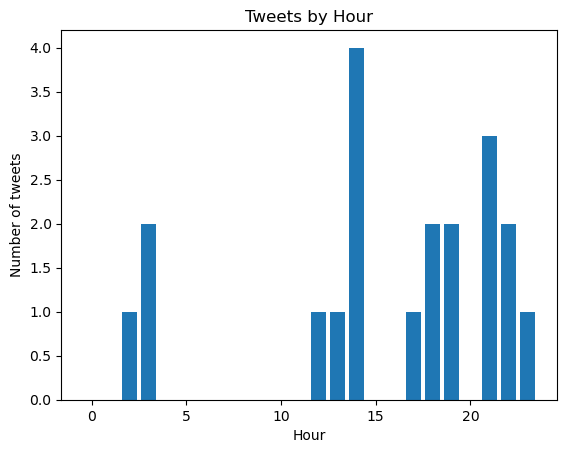

```python
from matplotlib import pyplot as plt

plt.bar(hourly_counts.keys(), hourly_counts.values())
plt.xlabel("Hour")
plt.ylabel("Number of tweets")
plt.title("Tweets by Hour")
plt.show()
```

### Exercise: Who's tweeting?

It appears that there are different sources for the tweets in the `source` field of the data.

Create an hourly count of tweets by the different sources. Can you infer what this suggests about Trump's personal phone and the one his office uses for tweeting?

Let's first find all the sources that are in the data.

```python
sources = set()
for tweet in tweet_data:
    if tweet['source'] not in sources:
        sources.add(tweet['source'])
print(sources)
```

```
{'Twitter for iPhone', 'Twitter for Android'}
```

Which are the most common sources and what do their timings suggest about usage?

```python
# Your code here
# Initialize dictionary (or multiple) like above
# Loop through tweets and add to counts like above

hourly_counts_iphone = {hour:0 for hour in range(24)}
hourly_counts_android = {hour:0 for hour in range(24)}

for tw in tweet_data:
    date_str = tw['created_at']

    dt = datetime.strptime(date_str,'%a %b %d %H:%M:%S +0000 %Y') # specify format of time string
    if tweet['source'] == 'Twitter for iPhone':
        hourly_counts_iphone[dt.hour] += 1
    elif tweet['source'] == 'Twitter for Android':
        hourly_counts_android[dt.hour] += 1
```

```python
hourly_counts_iphone
```

```
{0: 0,
 1: 0,
 2: 1,
 3: 2,
 4: 0,
 5: 0,
 6: 0,
 7: 0,
 8: 0,
 9: 0,
 10: 0,
 11: 0,
 12: 1,
 13: 1,
 14: 4,
 15: 0,
 16: 0,
 17: 1,
 18: 2,
 19: 2,
 20: 0,
 21: 3,
 22: 2,
 23: 1}
```

```python
hourly_counts_android
```

```
{0: 0,
 1: 0,
 2: 0,
 3: 0,
 4: 0,
 5: 0,
 6: 0,
 7: 0,
 8: 0,
 9: 0,
 10: 0,
 11: 0,
 12: 0,
 13: 0,
 14: 0,
 15: 0,
 16: 0,
 17: 0,
 18: 0,
 19: 0,
 20: 0,
 21: 0,
 22: 0,
 23: 0}
```

### Exercise: Who's tweeting what?

How do the contents of Mr Trump's tweets change depending on the source? We could do some really sophisticated analysis here through [sentiment analysis](http://text-processing.com/demo/sentiment/) of the tweet texts. For the purposes of this exercise, do the following calculations by tweet source:

1. Find the fraction of tweets containing the word 'dumb' in either upper or lower case.
2. Repeat for words you'd like, for example the ones suggested below.

You can also repeat the analysis by source and hour, or look at different words or mentions of different Twitter users.

Note you probably want to count both upper and lower case words together.

```python
# Your code here
words = ['dumb', 'brexit', '#makeamericagreatagain', 'guns', 'dead', '#crookedhillary', 'obama', 'u.s.', 'happy']

fraction = [0]*len(words)

for tw in tweet_data:
    for index, word in enumerate(words):
        if tw['text'].lower().find(word) != -1:
            fraction[index] += 1

fr = [fr / len(tweet_data) for fr in fraction]

print(fraction)
print(fr)
```

```
[0, 0, 0, 0, 0, 0, 2, 2, 4]
[0.0, 0.0, 0.0, 0.0, 0.0, 0.0, 0.1, 0.1, 0.2]
```

# Web Scraping Jupyter Notebook

*Data Structures and Algorithms*

*Imperial College Business School*

In this optional tutorial we'll learn the basics of web scraping with Python using the `BeautifulSoup` and `requests` libraries.

**Readings**

Sweigart, Al. Automate the Boring Stuff with Python.

- Chapter 11 - Web scraping https://automatetheboringstuff.com/chapter11/

Murray, Scott. Interactive Data Visualization on the Web.

- http://chimera.labs.oreilly.com/books/1230000000345/index.html
- Chapter 3 only, until Javascript

Berlind, David. What Are APIs and How Do They Work?

- https://www.programmableweb.com/api-university/what-are-apis-and-how-do-they-work

## Submission

This tutorial is optional and meant to be open-ended, and you don't need to submit anything.

## Accessing the web with Python

Most websites are written in HTML, which stands for HyperText Markup Language. These pages have the extension `.html` in our browser. An HTML file is a type of a text file, which includes the content of a web page, but also instructions for the browser on how to display the content, for example in paragraphs, tables, bold font, links, and so on.

When we access a web page with Python, we'll replicate the steps that our web browser does when we visit a page. We contact a website and download the HTML text. We'll then take advantage of the HTML structure (e.g. identifiers for links) to extract the information we're interested in.

The process of programmatically gathering data from websites is often called *scraping* the web. If we need to download data from many pages, or repeatedly, this automating web access using Python libraries can be a very powerful. However, as we will see, parsing information from HTML files can be fragile and cumbersome. For web sites that provide direct ways to access their data in more structured form through, access through their APIs is typically a much better choice.

We'll first go through the basics of HTML and Python's web access libraries. We'll then look at the important problem of finding a good breakfast in the UK.

### HTML basics

HTML files are just text files, but how is HTML different from regular text then? Here is an example of three paragraphs in plain text and in HTML.

Text:

```
Hello, world!

Hello again.

An example page: http://www.example.com/
```

Same in HTML:

```
<p>Hello, world!</p>

<p>Hello again.</p>

<p><a href="http://www.example.com/">An example page</a></p>
```

In addition to the text content, the HTML version contains **tags**. These are contained within angle brackets: the tag `<p>` is a starting tag, and `</p>` is the corresponding ending tag. In between the tags, there is the content of the *(p)aragraph* of text.

These tags can be nested.

```
<p>Hello, <strong>world!</strong></p>

<p>Hello again.</p>
```

Here `<p>` and `<strong>` are *parent* and *child* tags, and the two `<p>` tags are *sibling* tags.

Tags can further have **attributes**. For example, the hyperlink tag `<a>` (where "a" is for "anchor") specifies the target URL as the `href` attribute in the opening tag:

```
<p><a href="http://www.example.com/">An example page</a></p>

<p id="myid">Hey there</p>
```

Web sites use custom attributes to make content look fancy with CSS (cascading style sheets): for example, they can determine how all elements with the `id` attribute `myid` look (the `class` attribute is also common for CSS styling). The syntax of these is the name of the attribute, followed by an equals sign, followed by a quoted value. Attributes are always placed in the opening tag.

### Parsing HTML with BeautifulSoup

We have seen how we can loop through text, split it into words, and so on. We can similarly parse a HTML file to extract information we're looking for. Luckily, there are great libraries that automate much of this process for us.

We'll use the BeautifulSoup 4 library. Similarly to a web browser, Beautiful Soup takes advantage of the tag structure of the web page, not to display it, but to find the information that we'd like to store. For example, we may want to find all the links in a web page, so we would look for all the `<a href...>` tags.

Let's import the library and parse some HTML text. The code below creates a `BeautifulSoup` object that the Beautiful Soup library works with.

```python
from bs4 import BeautifulSoup
html = '<p>Hello, world!</p> <p>Hello again.</p>'
soup = BeautifulSoup(html, 'lxml') # two arguments: text and 'lxml', which is the html parser BS uses
print(soup.text)
print(type(soup))
```

```
Hello, world! Hello again.
<class 'bs4.BeautifulSoup'>
```

We can find the text contained in the data through the `text` attribute. What if we want to find all tags, here the paragraph tags? We can use the `find_all` method from the library.

```python
paragraphs = soup.find_all('p') # find all <p> tags
print(paragraphs)
print(type(paragraphs)) # this is an augmented list-type object
```

```
[<p>Hello, world!</p>, <p>Hello again.</p>]
<class 'bs4.element.ResultSet'>
```

The result is a list-type object which contains the tags. We can access it just like a list, and get the text of the contents.

```python
first = paragraphs[0]
print(first.name)
print(first.text)
print(type(first))
```

```
p
Hello, world!
<class 'bs4.element.Tag'>
```

In practice, finding the right tags often involves some detective work in deciding which tags we're looking for. Suppose that we're interested in scraping information from the website www.example.com. The website is simple, with just one link on the page. If we want to see how the underlying HTML looks like, we can access this information in our browser's *developer tools*; in most browsers the shortcut for viewing the source HTML of a page is `Ctrl + U`. In the example domain, a snippet of the HTML containing the displayed text looks like this:

```
<div>
    <h1>Example Domain</h1>
    <p>This domain is established to be used for illustrative examples in documents. You may use this
    domain in examples without prior coordination or asking for permission.</p>
    <p><a href="http://www.iana.org/domains/example">More information...</a></p>
</div>
```

Viewing the HTML like this is useful for deciding which tags we may want to search for.

### Browsing with Python

We'll use the `requests` library to access web pages. It downloads the web page, here the one at www.example.com.

```python
import requests
r = requests.get('http://www.example.com')
```

The result, stored into the variable `r`, is an object containing the raw html string. We can access through the `text` attribute.

```python
print(r.ok) # was the download attempt successful
r.text # raw HTML
```

```
True
```

```
'<!doctype html><html lang="en"><head><title>Example Domain</title><meta name="viewport" content="width=device-width, initial-scale=1"><style>body{background:#eee;width:60vw;margin:15vh auto;font-family:system-ui,sans-serif}h1{font-size:1.5em}div{opacity:0.8}a:link,a:visited{color:#348}</style></hea…
```

Now we can use Beautiful Soup to find all the links in the page.

```python
soup = BeautifulSoup(r.text, 'lxml')
links = soup.find_all('a')
print(links)
```

```
[<a href="https://iana.org/domains/example">Learn more</a>]
```

Now, we'd like to access the actual link, that is, the `href` attribute for the link. We can get to this with the `attrs` attribute of each of the found links. This is a dictionary of attribute-value pairs, and we can get the relevant one by accessing the `href` key.

```python
first_link = links[0]
print(first_link.text)
print(first_link.attrs) # dictionary of attributes
print(first_link.attrs['href'])
```

```
Learn more
{'href': 'https://iana.org/domains/example'}
https://iana.org/domains/example
```

Next, let's look at a more realistic example of finding information in a web page.

### Example: Best UK breakfasts from the Guardian

[This article from the Guardian](https://www.theguardian.com/lifeandstyle/2017/jan/15/50-best-breakfasts-uk) purports to list the 50 best breakfasts in the UK. The list is interesting, but it is in an unstructured form. If we wanted to remember these whenever we're visiting a different city, we'd probably like to store them in a file on our computer or online for easy access. We'll use Python to make this transformation.

The web page lists the restaurants, giving links, locations, and a short description of each. Let's look at how the underlying HTML file looks like. When viewing a web page in a browser, we can typically do this with the shortcut `Ctrl + U`. This will open the HTML source in a new tab.

The file is huge, with 3000 lines of text. We won't go into details of the HTML here, but instead look for the part in the file where the restaurants are presented. The first restaurant is in "Lewannick", so let's look for that in the source with `Ctrl + F`. We see the following result.

```
<h2><strong><a href="http://www.coombesheadfarm.co.uk/" data-link-name="in body link" class="u-underline">Coombeshead Farm</a></strong><strong>, Lewannick, Cornwall</strong><br></h2>
<p>It might seem a bit bonkers to include an upmarket B&amp;B (from £90 a night) that doesn’t offer breakfast to non-residents (for the time being), but Coombeshead earns its place here because it does possibly the best breakfast in the UK, and certainly this writer’s favourite of 2016 anywhere.</p>
```

Compare this to the website as it is displayed in your browser and try to link the different parts together.

Let's try to understand the first restaurant details from the HTML code. Above, the text ", Lewannick, Cornwall" is packaged in between the HTML *tags* `<strong>` and `</strong>`. The web browser uses HTML tags to display contents in a specific way, here in **bold** font. The tag `<strong>` is the opening tag which starts the emphasized text, and `</strong>` with a slash is the closing tag which ends the emphasis.

Similarly, the text "Coombeshead Farm" is packaged in between the tags `<a>` and `</a>`:

```
<a href="http://www.coombesheadfarm.co.uk/" data-link-name="in body link" class="u-underline">Coombeshead Farm</a>
```

As we've seen, this is the HTML way of specifying a link to another page. The tag `<a href="http://www.coombesheadfarm.co.uk/">` is the opening tag which creates the link to the restaurant's website. The tag `</a>` closes the tag: in between these, the text "Coombeshead Farm" is what gets displayed on the web page as the link text. Here, the tag has three *attributes*: `href` specifying the link address, and `data-link-name="in body link"` and `class="u-underline"`, which the browser uses to determine how the link is shown.

There are many different HTML tags, which the web browser uses to display contents in a specific way. We don't need to know their meanings for scraping purposes; we will simply use them to pick the data we'd like from the page.

### Getting the data

Let's download the HTML text using the `requests` library. The code below fetches the page, and stores the result in `r`, which is a "response" object that the library creates. The object has a `text` attribute, which contains the HTML of the page.

```python
import requests
r = requests.get("https://www.theguardian.com/lifeandstyle/2017/jan/15/50-best-breakfasts-uk")
r.text[:500]
```

```
'<!doctype html>\n        <html lang="en" data-article-theme="Lifestyle">\n            <head>\n\t\t\t    <!-- Hello there, HTML enthusiast! -->\n\n\t\t\t\t<!-- DCR commit hash 121101400b45772973f5d80c404e3db8d7a6f571 -->\n\n                <title>The 50 best breakfast places in the UK | Restaurants …
```

Let's use Beautiful Soup to parse the text. The code below creates a `soup` object that the Beautiful Soup library works with.

```python
from bs4 import BeautifulSoup
soup = BeautifulSoup(r.text, 'lxml')
```

### Collecting restaurants

We'd like to get all 50 restaurants' names, locations, and websites. Let's take another look at the HTML source.

```
<h2><strong><a href="http://www.coombesheadfarm.co.uk/" data-link-name="in body link" class="u-underline">Coombeshead Farm</a></strong><strong>, Lewannick, Cornwall</strong><br></h2>
<p>It might seem a bit bonkers to include an upmarket B&amp;B (from £90 a night) that doesn’t offer breakfast to non-residents (for the time being), but Coombeshead earns its place here because it does possibly the best breakfast in the UK, and certainly this writer’s favourite of 2016 anywhere.</p>
```

It looks like the structure of the data we'd like is roughly the following.

```
<h2><strong><a href="WEBPAGE LINK" data-link-name="in body link" class="u-underline">RESTAURANT NAME</a></strong><strong>, LOCATION</strong><br></h2>
```

There's an outer `<h2>` tag which specifies a header, a `<strong>` tag and an `<a>` tag fpr the link and the name, and another `<strong>` tag for the location.

We'd like to pick the three capitalized parts for all restaurants. We can search for tags in Beautiful Soup as follows.

```python
results = soup.find_all('h2') # find all h2 tags
print(results[0:2])
```

```
[<h2 class="dcr-n4qeq9" id="coombeshead-farm-lewannick-cornwall"><strong><a href="http://www.coombesheadfarm.co.uk/" style="color:inherit">Coombeshead Farm</a></strong><strong>, Lewannick, Cornwall</strong><br/></h2>, <h2 class="dcr-n4qeq9" id="cafe-alf-resco-dartmouth-devon"><a href="http://cafealf…
```

Let's see how we can extract the information we want from each restaurant. We can take the first result we found, and apply Beautiful Soup's find method to it again to find (the first) link. The link will have the *attribute* text and contain the actual link as `link['href']`.

```python
# Find link in first result
link = results[0].find('a') # find link
name = link.text # get text
url = link['href'] # get link address
print(name, url)

# Find the location
location = results[0].find_all('strong')[1].text
location = location.lstrip(' ,') # get rid of leading comma and space
print(location)
```

```
Coombeshead Farm http://www.coombesheadfarm.co.uk/
Lewannick, Cornwall
```

### Scraping is messy

Now try to write a loop that repeats this for all the restaurants. Store the results in a list containing dictionary entries as follows:

```
[{'Restaurant':name, 'Web page':url, 'Location':location}]
```

At some point you will run into trouble. This is because we have not just picked all restaurants, but other things in the article that also have the `<h2>` tag. Some of the results will thus not contain the information we want, and we need to prune them further. Try to work your loop around this, and other issues you'll run into, to pick the 50 restaurants.

```python
# Your code here
result_list = []

for result in results:
    # Find link in result
    try:
        link = result.find('a') # find link
        name = link.text # get text
        url = link['href'] # get link address
    except AttributeError:
        name = None
        url = None

    # Find the location
    try:
        location = result.find_all('strong')[1].text
        location = location.lstrip(' ,') # get rid of leading comma and space
    except IndexError:
        try:
            location = result.find('strong')
            location = location.text
            location = location.lstrip(' ,') # get rid of leading comma and space
        except AttributeError:
            location = None

    result_list.append({'Restaurant': name, 'Web page': url, 'Location': location})

result_list = [dict for dict in result_list if dict['Restaurant'] is not None]
print(result_list)
```

```
[{'Restaurant': 'Coombeshead Farm', 'Web page': 'http://www.coombesheadfarm.co.uk/', 'Location': 'Lewannick, Cornwall'}, {'Restaurant': 'Café Alf Resco', 'Web page': 'http://cafealfresco.co.uk/page/eat', 'Location': 'Dartmouth, Devon'}, {'Restaurant': 'Venus Cafe,', 'Web page': 'http://www.lovingthe…
```

Once you have your results, you can use the following code to write the dictionary into a csv file with the `csv` library.

```python
import csv

# File column names
csv_columns = ['Location','Restaurant','Web page']

with open('best_breakfast_guardian.csv', 'w', newline='') as csvfile:
    writer = csv.DictWriter(csvfile, fieldnames=csv_columns)
    writer.writeheader() # header row
    for rest in result_list: # rest of rows
        writer.writerow(rest)
```

What if we also wanted to store the description of each restaurant? One approach to do so is to use the hierarchical structure of the file's HTML tags with Beautiful Soup. We say that the tags at the same level in the hierarchy as our current tag are *siblings*, while those above (nesting the current tag) are *parents* and those below (inside the current tag) are *children*.

Inspecting the HTML, we see that the tags between two `<h2>` tags are `<p>` tags for paragraphs. Starting from a `<h2>` tag, we can loop through the paragraphs with the `next_sibling` attribute until we run into the next `<h2>` tag.

```python
current = results[0]

text = ''
# Loop until find next restaurant, ie h2 tag
while current.next_sibling.name != 'h2':
    print(current.next_sibling) # Either <p> or a new line
    current = current.next_sibling
    if current.name is not None: # Only get the paragraph text
        text += current.text + ' ' # Add a space between paragraphs
print('\nHere\'s the full text:\n')
print(text)
```

```
<div id="sign-in-gate"></div>
<p class="dcr-130mj7b">It might seem a bit bonkers to include an upmarket B&amp;B (from £90 a night) that doesn’t offer breakfast to non-residents (for the time being), but Coombeshead earns its place here because it does possibly the best breakfast in the UK, and certainly this writer’s favourite o…
<p class="dcr-130mj7b">The love child of two celebrated chefs, <a data-link-name="in body link" href="http://aprilbloomfield.com/">April Bloomfield</a> (of The Spotted Pig and The Breslin in New York) and Tom Adams (of <a data-link-name="in body link" href="http://www.pittcue.co.uk/">Pittcue in Lond…
<p class="dcr-130mj7b">From the granola, bircher muesli, honey and on-trend kombucha (for those who like that kind of thing) to the outrageously brilliant cooked offering – which comprises a thick slice of home-cured belly bacon, a pillow of scrambled eggs (most likely laid that morning by the chook…
<p class="dcr-130mj7b">The dinners (Thursday to Sunday nights) are something else, too, and you don’t have to stay over to tuck into those. <br/><strong>What to order:</strong> Everything.</p>

Here's the full text:

 It might seem a bit bonkers to include an upmarket B&B (from £90 a night) that doesn’t offer breakfast to non-residents (for the time being), but Coombeshead earns its place here because it does possibly the best breakfast in the UK, and certainly this writer’s favourite of 2016 anywhere. The love …
```

## Summary

As you've seen with the example, web scraping can easily get messy. The less structured the data that we're trying to gather is, the more tricky it is to parse it. In practice, web scraping works best for

- Structured pages. The page we've just scraped is a text article with some header structure. Scraping data from tables or other more structured forms is often much easier.
- Static pages. Accessing dynamic content (eg JavaScript) is often impossible through the standard HTML approach we have used. Alternative ways exist, but require more work.

Compared to downloading a file or using an API, web scraping is a fragile way to access a site. The HTML page could be changed, breaking your scraper, whereas APIs are often well maintained and robust.

You'll have noticed that it would be very easy to crawl through a lot of pages on a site very quickly by looping requests. This could be on a news website, or for example looking for business analytics positions on an online jobs platform. Before you do this, note that many websites don't like crawlers: The Guardian's business model, for instance, depends on ad revenues, so they don't like their content being automatically accessed. Here we've downloaded just one page, but if you ran a big scraping operation on them, they might ban you (and your flatmates). They do have an [API](http://open-platform.theguardian.com/access/) for accessing content.

In brief, scraping can be a powerful tool, but if there's an alternative way to get the data you need, don't scrape manually. If you do scrape data, be nice to the website and follow their terms of access.

Here are some further resources on scraping:

- [Automate the Boring Stuff has a detailed chapter on scraping](https://automatetheboringstuff.com/chapter11/)
- [The Beautiful Soup documentation](http://www.crummy.com/software/BeautifulSoup/bs4/doc/) is very well written
- [A success story with scraping](https://www.wired.com/2014/01/how-to-hack-okcupid/all/)
- [A nice and well-documented application on the NY Times website](http://www.dataschool.io/python-web-scraping-of-president-trumps-lies/)
- [Web data collection tasks from Stanford's Computational Journalism lab](https://github.com/stanfordjournalism/search-script-scrape), mostly through various US government APIs

### Scraping challenge

Download the top 100 most popular books from Project Gutenberg as text files from [here](https://www.gutenberg.org/browse/scores/top). Hint: you'll need inspect the page HTML to figure out the right tags to find, and how to get to the text file following these links. Bonus: save the the files and analyse their content; for example, which of them has the longest average word length?

# DSA Homework 2

## Question 1: Buy and Hold (2p)

- Function takes as input a list of prices, a starting index, and a starting cash position
- It should return the value of the final position if the entire cash position is used to purchase stock at the starting index
- Suppose prices are `[2.0, 1.5, 1.8, 2.3, 2.5]`, starting index is `0`, and the starting cash is `100`
  - We buy stock at index `0` worth `100`
  - Since the price is `2`, we hold `50` units of stock
  - The value of our position then fluctuates with the stock price
    - At index `1`, it is $1.5 \cdot 50 = 75$
    - At index `2`, it is $1.8 \cdot 50 = 90$
    - So on until end of price list

```python
def buy_and_hold(prices, start_index=0, starting_money=100.0):
    """
    Buy and hold strategy


    Parameters:
        prices (list): stock prices
        start_index (positive integer, optional): index from which to start the strategy
        starting_money (float, optional): starting cash position. Defaults to 100.0.

    Returns:
        list containing value of position using buy and hold strategy

    Example use:
    >>> res = buy_and_hold([2.0, 1.5, 1.8, 2.3, 2.5])
    >>> [round(x, 1) for x in res]
    [100.0, 75.0, 90.0, 115.0, 125.0]
    >>> [round(x, 2) for x in buy_and_hold([2.0, 1.5, 1.8, 2.3, 2.5], start_index=2)]
    [100.0, 100.0, 100.0, 127.78, 138.89]
    """
    # Your code here. Don't change anything above.
    stock_units = 100.0 / prices[start_index]
    value = [p * stock_units for p in prices]
    if start_index != 0:
        for i in range(start_index):
            value[i] = 100.0
    return value
```

```python
res = buy_and_hold([2.0, 1.5, 1.8, 2.3, 2.5])
[round(x, 1) for x in res]
```

```
[100.0, 75.0, 90.0, 115.0, 125.0]
```

```python
[round(x, 2) for x in buy_and_hold([2.0, 1.5, 1.8, 2.3, 2.5], start_index=2)]
```

```
[100.0, 100.0, 100.0, 127.78, 138.89]
```

```python
range(2)
```

```
range(0, 2)
```

## Question 2: Moving Average (6p)

```python
def moving_average(prices, n):
    """
    Calculates n-period moving average of a list of floats/integers.

    Parameters:
        prices: list of values (ordered in time),
        n: integer moving-average parameter

    Returns:
        list with None for the first n-1 values in prices and the appropriate moving average for the rest

    Example use:
    >>> ma = moving_average([2,3,4,5,8,5,4,3,2,1], 3)
    >>> [round(m, 2) if m is not None else None for m in ma]
    [None, None, 3.0, 4.0, 5.67, 6.0, 5.67, 4.0, 3.0, 2.0]
    >>> moving_average([2,3,4,5,8,5,4,3,2,1], 2)
    [None, 2.5, 3.5, 4.5, 6.5, 6.5, 4.5, 3.5, 2.5, 1.5]
    """
    # Your code here. Don't change anything above.
    prices = [float(p) for p in prices]
    ma = [None] * len(prices)
    for i in range(n - 1, len(prices)):
        ma[i] = sum(prices[i+1-n:i+1])/n
    return ma
```

```python
ma = moving_average([2,3,4,5,8,5,4,3,2,1], 3)
[round(m, 2) if m is not None else None for m in ma]
```

```
[None, None, 3.0, 4.0, 5.67, 6.0, 5.67, 4.0, 3.0, 2.0]
```

```python
moving_average([2,3,4,5,8,5,4,3,2,1], 2)
```

```
[None, 2.5, 3.5, 4.5, 6.5, 6.5, 4.5, 3.5, 2.5, 1.5]
```

## Question 3: Comparing MAs for crossovers (6p)

```python
def compare_mas(ma1, ma2):
    """
    Compare two moving averages.

    Compares values in ma1 and ma2 pairwise to create a list of indicators such that
    - If ma1 > ma2, indicator = 1
    - Otherwise indicator = 0
    - The moving averages may contain None-values in the beginning. If either value is None, the indicator is None

    Parameters:
        ma1 (list): moving average (list of prices)
        ma2 (list): moving average (list of prices)

    Returns:
        list: binary indicators for which moving average value is greater

    Example use:
    >>> p1 = [1, 2, 4, 5]
    >>> p2 = [0, 2.5, 5, 3]
    >>> compare_mas(p1, p2)
    [1, 0, 0, 1]
    >>> p1 = [None, 2.5, 3.5, 4.5, 4.5, 3.5, 2.5, 1.5, 3.5, 3.5]
    >>> p2 = [None, None, 3.0, 4.0, 4.33, 4.0, 3.0, 2.0, 3.0, 2.66]
    >>> compare_mas(p1, p2)
    [None, None, 1, 1, 1, 0, 0, 0, 1, 1]
    """
    # Your code here. Don't change anything above.
    return [int((m1 - m2) > 0) if (m1 != None and m2 != None) else None for m1, m2 in zip(ma1, ma2)]
```

```python
p1 = [1, 2, 4, 5]
p2 = [0, 2.5, 5, 3]
compare_mas(p1, p2)
```

```
[1, 0, 0, 1]
```

```python
p1 = [None, 2.5, 3.5, 4.5, 4.5, 3.5, 2.5, 1.5, 3.5, 3.5]
p2 = [None, None, 3.0, 4.0, 4.33, 4.0, 3.0, 2.0, 3.0, 2.66]
compare_mas(p1, p2)
```

```
[None, None, 1, 1, 1, 0, 0, 0, 1, 1]
```

## Question 4: Trading based on moving averages (6p)

```python
def ma_strategy(prices, comparisons, starting_cash=100.0):
    """
    Trade based on moving average crossovers

    Parameters:
        prices: list if stock prices
        comparisons: list of comparisons from compare_mas
        starting_cash (float, optional): Starting cash position, defaults to 100.0.

    Returns:
        list of values of the current position: either cash position or the market value of stock position

    We initially hold cash, and buy when we first get a signal to buy.

    More specifically, a change from value 0 to 1 in comparisons signals there's a crossover in moving averages, so we want to buy stock. A move from 1 to 0 signals that we want to sell stock.

    Whenever we trade, we buy with our entire cash position, or sell our entire stock position.
    We will therefore always hold either stock or cash, but never both.

    Assume we can hold fractional stock quantities, and there are no transaction fees.

    Example use:
    >>> starting_cash = 1.0
    >>> prices = [2,4,6,5,1]
    >>> cos = [0, 1, 1, 0, 0] # not real indicators, just to illustrate portfolio value when trading
    >>> values = ma_strategy(prices, cos, starting_cash)
    >>> values
    [1.0, 1.0, 1.5, 1.25, 1.25]
    >>> starting_cash = 1000.0
    >>> prices = [2,3,4,5,4,3,2,1,6,1,5,7,8,10,7,9]
    >>> cos = [None, None, 1, 1, 1, 0, 0, 0, 1, 1, 0, 1, 1, 1, 1, 0]
    >>> values = ma_strategy(prices, cos, starting_cash)
    >>> [round(v, 2) for v in values] # round every value of the returned list using list comprehension
    [1000.0, 1000.0, 1000.0, 1000.0, 1000.0, 1000.0, 1000.0, 1000.0, 1000.0, 166.67, 833.33, 833.33, 952.38, 1190.48, 833.33, 1071.43]
    """
    # Your code here. Don't change anything above.
    values = [starting_cash] * len(prices)
    first = 0
    bought = False
    for i in range(len(comparisons) - 1):
        if comparisons[i] != None:
            if comparisons[i + 1] - comparisons[i] == 1:
                first = 1
                bought = True
                stock_units = values[i] / prices[i + 1]
                values[i + 1] = values[i]
            elif (comparisons[i + 1] - comparisons[i] == -1) and first == 1:
                values[i + 1] = stock_units * prices[i + 1]
                bought = False
            else:
                if bought == False:
                    values[i + 1] = values[i]
                elif bought == True:
                    values[i + 1] = stock_units * prices[i + 1]
    return values
```

```python
starting_cash = 1.0
prices = [2,4,6,5,1]
cos = [0, 1, 1, 0, 0] # not real indicators, just to illustrate portfolio value when trading
values = ma_strategy(prices, cos, starting_cash)
values
```

```
[1.0, 1.0, 1.5, 1.25, 1.25]
```

```python
starting_cash = 1000.0
prices = [2,3,4,5,4,3,2,1,6,1,5,7,8,10,7,9]
cos = [None, None, 1, 1, 1, 0, 0, 0, 1, 1, 0, 1, 1, 1, 1, 0]
values = ma_strategy(prices, cos, starting_cash)
[round(v, 2) for v in values]
```

```
[1000.0,
 1000.0,
 1000.0,
 1000.0,
 1000.0,
 1000.0,
 1000.0,
 1000.0,
 1000.0,
 166.67,
 833.33,
 833.33,
 952.38,
 1190.48,
 833.33,
 1071.43]
```

### Question 5: Trading Floor Analytics (10p)

```python
def trading_floor(visits, option=2):
    """
    Produce summary statistics of trading desk utilisation.

    Parameters:
        visits: list of visits (see also HTML instructions):
            Each visit is a tuple (desk number (str), trader ID (str), time (str)) (all elements are integers in string format)
            Each trader starts outside any desk, and they leave all desks at the end of the day.
            The visits are not necessarily in chronological order.
        option (int, optional): determines what to return, see below

    Returns:
        a list containing tuples for each trading desk (sorted in increasing order by desk number (1, 2, 3, ...)):
        - if option = 0, (desk number, number of distinct traders)
        - if option = 1, (desk number, number of distinct traders, average visit duration)
        - if option = 2, (desk number, number of distinct traders, average visit duration, longest total time spent at the desk by a single trader)
        - the average visit duration is rounded to the nearest minute.

    Example use:
    >>> visits = [('0', '0', '20'), ('0', '0', '25'), ('1', '1', '74'), ('1', '1', '2')]
    >>> trading_floor(visits)
    [('0', 1, 5, 5), ('1', 1, 72, 72)]
    >>> trading_floor(visits, 0)
    [('0', 1), ('1', 1)]
    >>> trading_floor(visits, 1)
    [('0', 1, 5), ('1', 1, 72)]
    >>> trading_floor(visits, 1)[0]
    ('0', 1, 5)
    >>> visits = [('15', '3', '61'), ('15', '3', '45'), ('6', '0', '91'), ('10', '4', '76'), ('6', '0', '86'), ('6', '4', '2'), ('10', '1', '47'), ('6', '3', '17'), ('6', '4', '41'), ('15', '3', '36'), ('6', '2', '97'), ('15', '4', '58'), ('6', '0', '16'), ('10', '2', '21'), ('10', '4', '75'), ('6', '0', '76'), ('15', '4', '50'), ('10', '1', '64'), ('6', '3', '3'), ('15', '3', '35'), ('6', '2', '96'), ('10', '2', '35'), ('10', '2', '77'), ('10', '2', '48')]
    >>> trading_floor(visits)
    [('6', 4, 24, 65), ('10', 3, 15, 43), ('15', 2, 8, 17)]
    """
    visits = [(int(x[0]), int(x[1]), int(x[2])) for x in visits]
    visits = sorted(visits)
    summary = [[str(i), set(), list()] for i in range(int(visits[-1][0]) + 1)]
    for i in range(len(visits) // 2):
        start = visits[i * 2]
        end = visits[i * 2 + 1]
        desk_number = int(start[0])
        trader = start[1]
        visit_duration = int(end[2]) - int(start[2])
        if summary[desk_number][1] == set():
            summary[desk_number][1] = set()
            summary[desk_number][2] = list()
        if trader in summary[desk_number][1]:
            element = next(x for x in summary[desk_number][2] if x[0] == trader)
            index = summary[desk_number][2].index(element)
            summary[desk_number][2][index] = [element[0], element[1] + visit_duration]
            summary[desk_number][2].append([0, 0])
        else:
            summary[desk_number][1].add(trader)
            summary[desk_number][2].append([trader, visit_duration])
        summary[desk_number] = [str(desk_number), summary[desk_number][1], summary[desk_number][2]]
    summary = [x for x in summary if x[1] != set()]
    if option == 0:
        return [(x[0], len(x[1])) for x in summary]
    if option == 1:
        return [(x[0], len(x[1]), round(sum([visit[1] for visit in x[2]]) / len(x[2]))) for x in summary]
    if option == 2:
        return [(x[0], len(x[1]), round(sum([visit[1] for visit in x[2]]) / len(x[2])), max([visit[1] for visit in x[2]])) for x in summary]
```

```python
visits = [('0', '0', '20'), ('0', '0', '25'), ('1', '1', '74'), ('1', '1', '2')]
trading_floor(visits)
```

```
[('0', 1, 5, 5), ('1', 1, 72, 72)]
```

```python
trading_floor(visits, 0)
```

```
[('0', 1), ('1', 1)]
```

```python
trading_floor(visits, 1)
```

```
[('0', 1, 5), ('1', 1, 72)]
```

```python
trading_floor(visits, 1)[0]
```

```
('0', 1, 5)
```

```python
visits = [('15', '3', '61'), ('15', '3', '45'), ('6', '0', '91'), ('10', '4', '76'), ('6', '0', '86'), ('6', '4', '2'), ('10', '1', '47'), ('6', '3', '17'), ('6', '4', '41'), ('15', '3', '36'), ('6', '2', '97'), ('15', '4', '58'), ('6', '0', '16'), ('10', '2', '21'), ('10', '4', '75'), ('6', '0', '76'), ('15', '4', '50'), ('10', '1', '64'), ('6', '3', '3'), ('15', '3', '35'), ('6', '2', '96'), ('10', '2', '35'), ('10', '2', '77'), ('10', '2', '48')]
trading_floor(visits)
```

```
[('6', 4, 24, 65), ('10', 3, 15, 43), ('15', 2, 8, 17)]
```